# Projekt I - predykcja

Tomasz Gałązka, Krystian Igras

7 grudnia 2016

##### Wczytujemy potrzebne pakiety i dane:

```r
library("caret")
library("party")
library("partykit")
library("rpart")
library("rpart.plot")
library("e1071")
library("ggplot2")

library("pROC")
library("randomForest")
library("xgboost")
library("glmnet")
setwd('D:\\RStudio\\projekt')
Dane<-read.csv('GlioblastomaWide.csv', sep=";")

set.seed(12345)
```

Pozbywamy sie zmiennych zawierajacych wiecej niz 30 wartosci “NA” dla pacjetow, którzy przeżyli lub nie przeżyli 1 roku. Pozostaje nam 15780 zmiennych.

```r
Dane$death1y<-as.numeric(ifelse(as.character(Dane$death1y)=='alive',1,0))

duzo_NaN_alive<-(colSums(is.na(Dane[Dane$death1y==1,]))>30)
duzo_NaN_dead<-(colSums(is.na(Dane[Dane$death1y==0,]))>30)
maska<- (duzo_NaN_alive | duzo_NaN_dead)

Dane2<-Dane[,!maska]
```

## Wybór istotnych zmiennych

W celu wyboru genow cechujacy sie rozna ekspresja, wykonalismy 10-krotnie test korelacji spearmana (poprawka ‘fdr’, poziom istotnosci 80%) przy czym:

- Najpierw przeprowadzamy test na wszystkich obserwacjach,
- Pozostale 9 na losowo wybranych podzbiorach obserwacji (75% danych, funkcja losowa “createDataPartition”).

W powyższych 10 testach, każda zmienna została uznana za istotną od 0 do 10 razy. Liczbę tych wyników zawiera wektor, który nazwaliśmy “sumarycznie”. Będzie on niejednokrotnie wykorzystywany w dalszych testach.

```r
sumarycznie<-numeric(ncol(Dane2)-4)

kortest<-apply(Dane2[,5:ncol(Dane2)], 2, function(x){cor.test(Dane2[,4],x, method="spearman", na.omit=TRUE, exact=FALSE)$p.value})
names(kortest)<-NULL

log_kortest<-p.adjust(kortest, method="fdr")<0.2

wynik<-log_kortest
sumarycznie<-sumarycznie + wynik

for (i in 1:9){

#Wybieranie pr?bki testowej
Podzial<-createDataPartition(Dane2$death1y, times=1, p=0.75, list=FALSE)

Dane3 <- Dane2[Podzial,]

kortest<-apply(Dane3[,5:ncol(Dane3)], 2, function(x){cor.test(Dane3[,4],x, method="spearman", na.omit=TRUE, exact=FALSE)$p.value})
names(kortest)<-NULL

log_kortest<-p.adjust(kortest, method="fdr")<0.2

wynik<-log_kortest
sumarycznie<-sumarycznie + wynik
}

y<-which(sumarycznie>=6)+4
```

Przykładowo zmienne, które zostały uznane za istotne w conajmniej 60%:

```
##  [1] "AQP9"    "CDCP1"   "CLEC5A"  "CPPED1"  "GPNMB"   "IFI44L"  "INSL3"
##  [8] "LILRB3"  "LSP1"    "MLPH"    "MYBPC2"  "PTPRN"   "SLC16A3" "SLC17A9"
## [15] "SLC6A6"  "TBL1XR1" "TM7SF4"  "ZNF569"
```

Boxploty dla pierwszych 6 spośród nich:

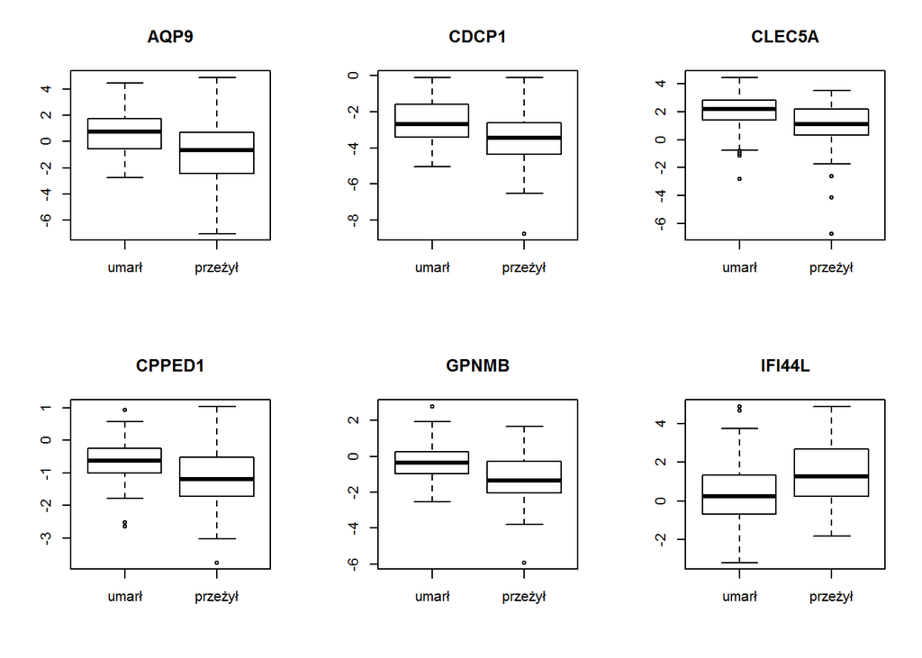

Ponieważ większość z wykorzystywanych klasyfikatorów, ma problem z funkcjonowaniem gdy w danych występują braki, zamienimy NA medianami, a następnie średnimi.

# Zamiana NA poprzez mediany.

```r
mediany<-apply(Dane2[,-(1:4)], 2, function(x){median(x, na.rm = TRUE)})
for (i in 1:nrow(Dane2)) {
  Dane2[i,-(1:4)][is.na(Dane2[i,-(1:4)])]<-mediany[is.na(Dane2[i,-(1:4)])]
}
```

## Wykorzystane klasyfikatory:

Testowaliśmy nastepujace klasyfikatory:

- drzewo ctree

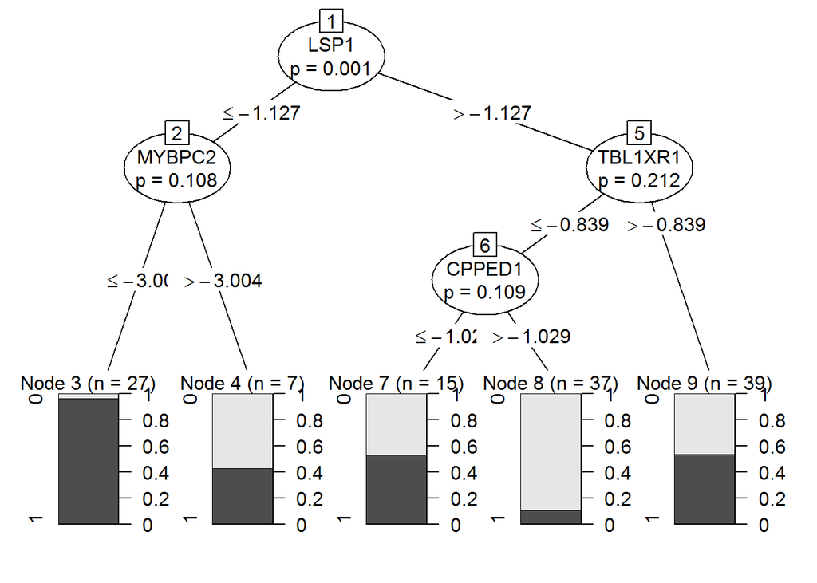

```r
Dan=Dane2[,c(4,y)]
Dan$death1y<-as.factor(Dan$death1y)
drzewo <- ctree(death1y~., data=Dan, control=ctree_control(mincriterion = 0.75, testtype="Bonferroni"))
plot(drzewo)
```

- drzewo rpart

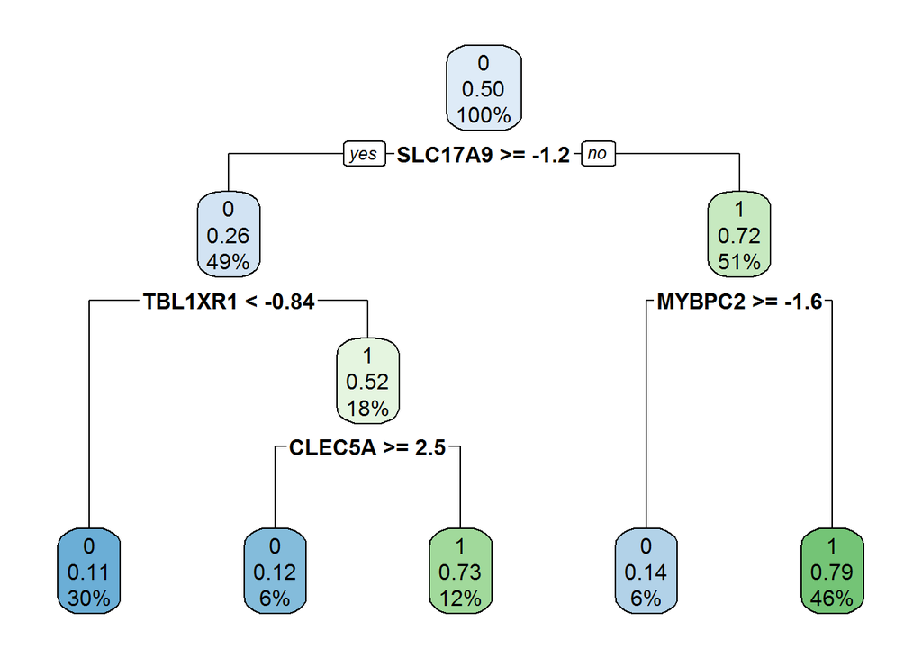

```r
drzewwo <- rpart(death1y~., data=Dan)
rpart.plot(drzewwo)
```

- naiveBayes
- regresja

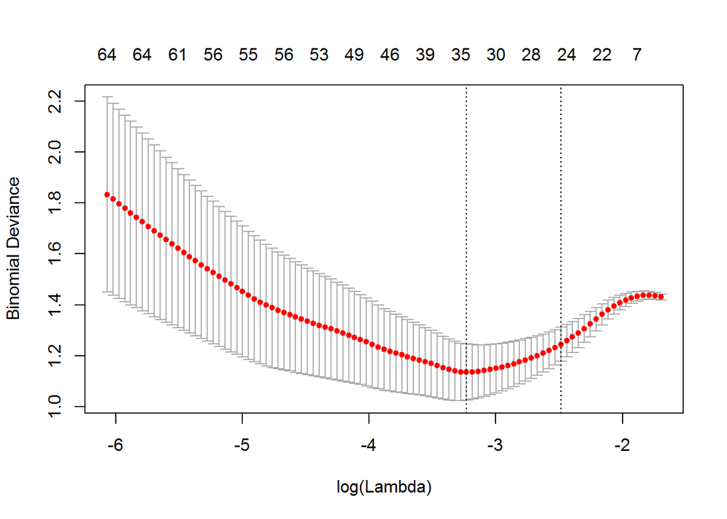

```r
set.seed(12345)

yreg<-which(sumarycznie>=2)+4
Danreg<-Dane2[,c(4,yreg)]
X <- as.matrix(Danreg[,-1])
X <- scale(X)

cvfit = cv.glmnet(x = X, y = Danreg$death1y == "1", family="binomial")
plot(cvfit)
```

```r
c<-coef(cvfit, s = "lambda.min")
waznereg<-rownames(c)[which(c != 0)[-1]]
Danreg<-Dane2[,c("death1y",waznereg)]
```

Oraz w ramach stacking:

- las losowy, ktory maksymalizuje wspolczynnik F1 (liczba drzew wybrana na podstawie oddzielnych testow)

```r
set.seed(12345)
y2=which(sumarycznie>=3)+4
Danlas<-Dane2[,c(4,y2)]

c<-list()
c[[45]] <-matrix(0,2,2)
wazne<-list()
  rf <- randomForest(death1y~., data=Danlas, ntree=330)
for (j in 14:44){

wazne[[j]]<-which(rf$importance>=(j+3)/99)
c[[j]] <- matrix(0,2,2)
}

for (i in 1:100){
subset<-createDataPartition(Danlas$death1y, p=0.75)$Resample1
Dan_ucz<-Danlas[subset,]
Dan_test<-Danlas[-subset,]

rf<-randomForest(death1y~., data=Dan_ucz, ntree=330)
pred_rf<-predict(rf, Dan_test)

t<-table(predykcja = pred_rf>.5, prawdziwe = Dan_test[,1])
c[[45]] = c[[45]]+t

# Zaw??amy baz? do tych zmiennych i wykonujemy to samo

for (j in 14:44){

Dan2<-Dane2[,c(4,y2[wazne[[j]]])]


# podzia? na zbiory ucz?ce i testowe robimy taki sam:
Dan_ucz2<-Dan2[subset,]
Dan_test2<-Dan2[-subset,]

# Tworzenie drzewa

rf2<-randomForest(death1y~., data=Dan_ucz2, ntree=330)

pred_rf2<-predict(rf2, Dan_test2)


t<-table(predykcja = pred_rf2>.5, prawdziwe = Dan_test2[,1])
c[[j]]=c[[j]]+t
}
}
for (j in 14:45){
c[[j]]=c[[j]]/100
}

d=matrix(0,32,3)
for (j in 14:45){
  d[j-13,1]<-c[[j]][1,1]/(c[[j]][1,1]+c[[j]][1,2])
  d[j-13,2]<-c[[j]][1,1]/(c[[j]][1,1]+c[[j]][2,1])
  d[j-13,3]<-(2*d[j-13,1]*d[j-13,2])/(d[j-13,1]+d[j-13,2])
}
lala<-which((max(d[,3])==d[,3])==TRUE)
wazne<-wazne[[lala+13]]
y2<-y2[wazne]
Danlas<-Dane2[,c(4,y2)]
```

- xgboost, który maksymalizuje współczynnik F1

```r
set.seed(12345)
subset<-createDataPartition(Dane2$death1y, p=0.75, times=100, list=FALSE)
xgb_test<-function(roundsy, depthy, istotnosc){

y3<-which(sumarycznie>=istotnosc)+4


Danregg=Dane2[,c(4,y3)]




igrek = Danregg$death1y == "1"
X = as.matrix(Danregg[,-1])
gb <- xgboost(data=X, label=igrek,
              objective = "binary:logistic",
              nrounds = roundsy,
              max.deph = depthy,
              verbose=0)

imp <- xgb.importance(colnames(Danregg)[-1], model = gb)

genow<-nrow(imp)

lista<-list()
for (i in 1:genow){
  lista[[i]]<-imp$Feature[1:i]
}



cs<-numeric(genow)

for (j in 4:(genow)){

  Danexg<-Danregg[,c("death1y",lista[[j]])]
  for (i in 1:100){


    X = as.matrix(Danexg[subset[,i],-1])
    gb <- xgboost(data=X, label=igrek[subset[,i]],
                  objective = "binary:logistic",
                  nrounds = roundsy,
                  max.depth = depthy,
                  verbose=0)
    pred<-predict(gb, as.matrix(Danexg[-subset[,i],-1]))

    t<-table(predykcja = (pred>0.5), prawdziwe = Danexg[-subset[,i],1])
    p<-t[1,1]/(t[1,1]+t[1,2])
    r<-t[1,1]/(t[1,1]+t[2,1])

    cs[j]=cs[j]+(2*p*r)/(p+r)

  }
}

return(list(lista[[genow]],cs))

}


zmienne<-new.env()

for (k in 3:7){
  for (l in 3:5) {
    assign(paste("k",k,"l",l,sep=""), xgb_test(k,l,2), envir = zmienne)
  }
}

wyniki<-as.list(zmienne)

maksy<-matrix(0,length(wyniki),3, dimnames=list(as.character(1:length(wyniki)),c("zmienna", "maksF1", "ile.zmiennych")))

for (i in 1:length(wyniki)) {
  maksy[i,1]<-names(wyniki[i])
  maksy[i,2]<-max(wyniki[[i]][[2]])
  maksy[i,3]<-which(wyniki[[i]][[2]]==maksy[i,2])
}

wiersz<-as.numeric(which(maksy[,2]==max(maksy[,2]))[1])
nazwy<-wyniki[[wiersz]][[1]][1:maksy[wiersz,3]]

Danxg<-Dane2[,c("death1y",nazwy)]
```

- XGB + Las (dwukrotna predykcja pacjentów, których wynik XGB był zbliżony do 0.5 - druga predykcja poprzez Las). Jednak wynik okazal sie przeciety i pominelismy w prezentowanych testach.

## Testowanie klasyfikatorów

- One-out leave (n-fold cv)
- Repeated k-fold CV
- Tablica kontyngecji (czułość, specyficzność, F1) oraz ROC (AUC) dla podzialu bootstrap (funkcja createResample)
- Tablica kontyngecji (czułość, specyficzność, F1) oraz ROC (AUC) dla podzialu standardowego (funkcja createDataPartition)

**1. n-fold**

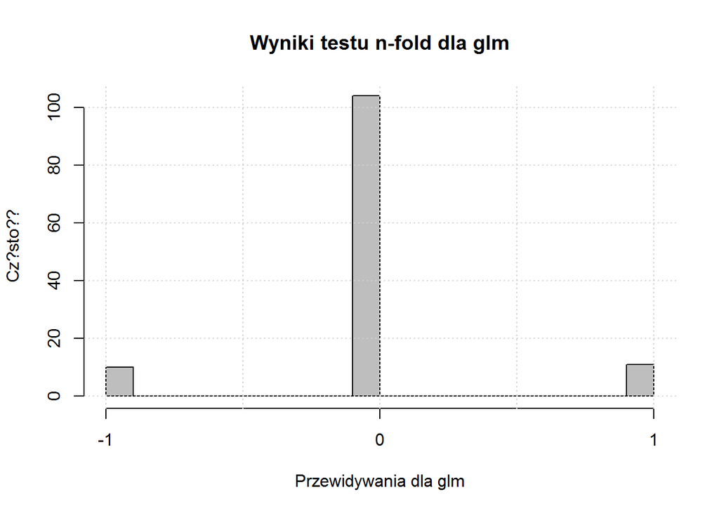

```r
foldy <- createFolds(Dane2$death1y, k=125)

wyn<-matrix(0,3,6)
colnames(wyn)<-c("glm", "ctree", "rpart", "naiveBayes","las", "xgboost")
rownames(wyn)<-c("1", "0", "-1")

errors1 <- lapply(foldy, function(ind) {
  model <- glm(death1y~., data=Danreg[-ind,], family = "binomial", control = list(maxit = 50))
predict(model, newdata=Danreg[ind,], "response")- (Danreg[ind,"death1y"] == "1")
})
wyn[1,1]<-length(which(round(unlist(errors1))==1))
wyn[2,1]<-length(which(round(unlist(errors1))==0))
wyn[3,1]<-length(which(round(unlist(errors1))==-1))
hist(round(unlist(errors1)), 20, main=paste("Wyniki testu n-fold dla", colnames(wyn)[1]), xlab = paste("Przewidywania dla", colnames(wyn)[1]), ylab = "Cz?sto??", col="gray", xaxt='n')
axis(side=1, at=-1:1, labels = c(-1,0,1))
grid()
```

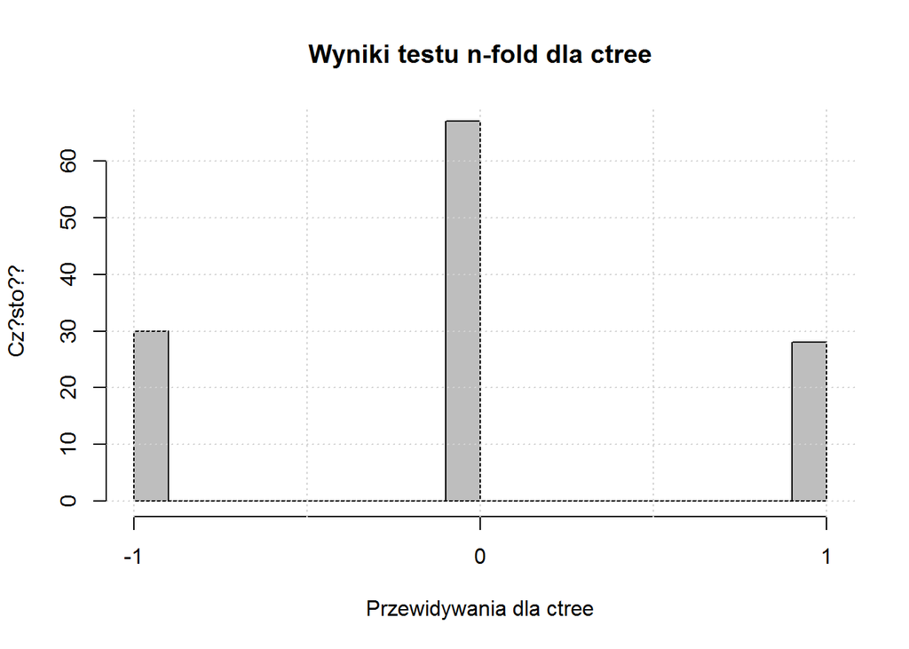

```r
errors2 <- lapply(foldy, function(ind) {
  model <- ctree(death1y~., data=Dan[-ind,], control=ctree_control(mincriterion = 0.75, testtype="Bonferroni"))
as.numeric(predict(model, newdata=Dan[ind,]))-as.numeric((Dan[ind,"death1y"]))
})
wyn[1,2]<-length(which(round(unlist(errors2))==1))
wyn[2,2]<-length(which(round(unlist(errors2))==0))
wyn[3,2]<-length(which(round(unlist(errors2))==-1))
hist(round(unlist(errors2)), 20, main=paste("Wyniki testu n-fold dla", colnames(wyn)[2]), xlab = paste("Przewidywania dla", colnames(wyn)[2]), ylab = "Cz?sto??", col="gray", xaxt='n')
axis(side=1, at=-1:1, labels = c(-1,0,1))
grid()
```

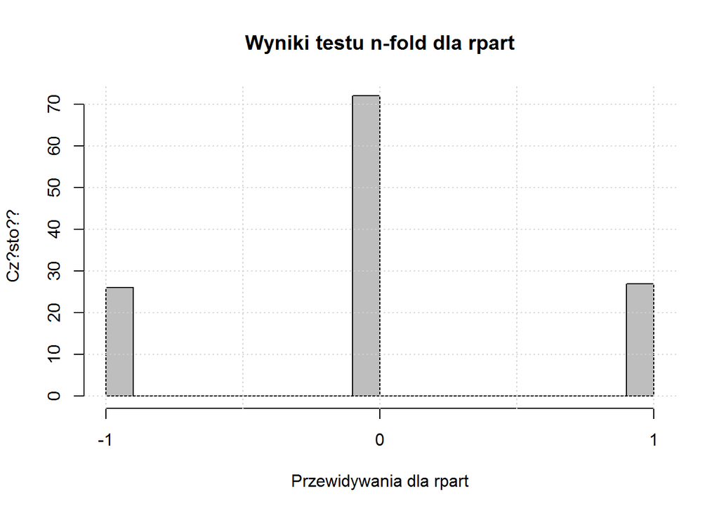

```r
errors3 <- lapply(foldy, function(ind) {
  model <- rpart(death1y~., data=Dan[-ind,])
as.numeric(predict(model, newdata=Dan[ind,], type="class"))-as.numeric((Dan[ind,"death1y"]))
})
wyn[1,3]<-length(which(round(unlist(errors3))==1))
wyn[2,3]<-length(which(round(unlist(errors3))==0))
wyn[3,3]<-length(which(round(unlist(errors3))==-1))
hist(round(unlist(errors3)), 20, main=paste("Wyniki testu n-fold dla", colnames(wyn)[3]), xlab = paste("Przewidywania dla", colnames(wyn)[3]), ylab = "Cz?sto??", col="gray", xaxt='n')
axis(side=1, at=-1:1, labels = c(-1,0,1))
grid()
```

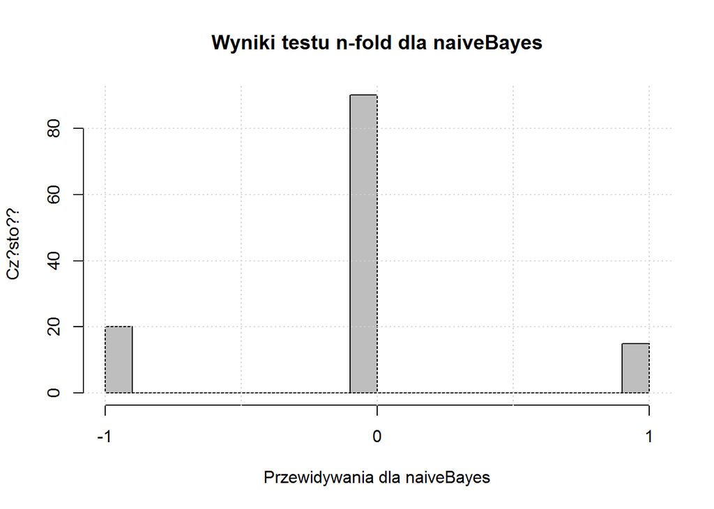

```r
errors4 <- lapply(foldy, function(ind) {
  model <- naiveBayes(death1y~., data=Dan[-ind,])
  as.numeric(predict(model, newdata=Dan[ind,]))-as.numeric((Dan[ind,"death1y"]))
})
wyn[1,4]<-length(which(round(unlist(errors4))==1))
wyn[2,4]<-length(which(round(unlist(errors4))==0))
wyn[3,4]<-length(which(round(unlist(errors4))==-1))
hist(round(unlist(errors4)), 20, main=paste("Wyniki testu n-fold dla", colnames(wyn)[4]), xlab = paste("Przewidywania dla", colnames(wyn)[4]), ylab = "Cz?sto??", col="gray", xaxt='n')
axis(side=1, at=-1:1, labels = c(-1,0,1))
grid()
```

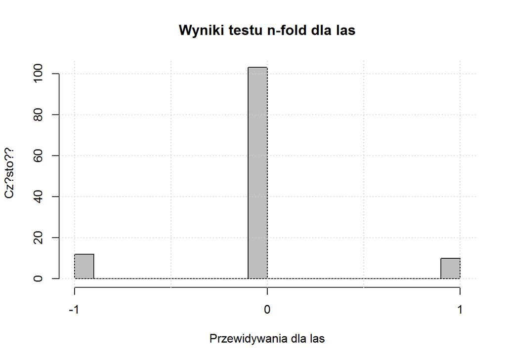

```r
errors5 <- lapply(foldy, function(ind) {
  model <- randomForest(death1y~., data=Danlas[-ind,], ntree=330)
  predict(model, newdata=Danlas[ind,], "response")-(Danlas[ind,"death1y"] == "1")
})
wyn[1,5]<-length(which(round(unlist(errors5))==1))
wyn[2,5]<-length(which(round(unlist(errors5))==0))
wyn[3,5]<-length(which(round(unlist(errors5))==-1))
hist(round(unlist(errors5)), 20, main=paste("Wyniki testu n-fold dla", colnames(wyn)[5]), xlab = paste("Przewidywania dla", colnames(wyn)[5]), ylab = "Cz?sto??", col="gray", xaxt='n')
axis(side=1, at=-1:1, labels = c(-1,0,1))
grid()
```

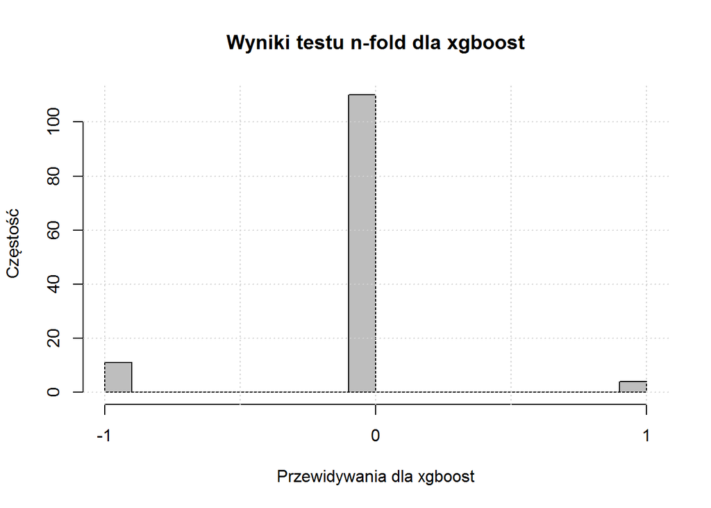

```r
igrek = Danxg$death1y == "1"
errors6 <- lapply(foldy, function(ind){
  X = as.matrix(Danxg[-ind,-1])
  model <- xgboost(data=X, label=igrek[-ind],
                  objective = "binary:logistic",
                  nrounds=3,
                  max.depth=4,
                  verbose=0)
  predict(model, as.matrix(Danxg[ind,-1]))-(Danxg[ind,"death1y"] == "1")
})
wyn[1,6]<-length(which(round(unlist(errors6))==1))
wyn[2,6]<-length(which(round(unlist(errors6))==0))
wyn[3,6]<-length(which(round(unlist(errors6))==-1))
hist(round(unlist(errors6)), 20, main=paste("Wyniki testu n-fold dla", colnames(wyn)[6]), xlab = paste("Przewidywania dla", colnames(wyn)[6]), ylab = "Częstość", col="gray", xaxt='n')
axis(side=1, at=-1:1, labels = c(-1,0,1))
grid()
```

Wynik testu:

```
##    glm ctree rpart naiveBayes las xgboost
## 1   11    28    27         15  10       4
## 0  104    67    72         90 103     110
## -1  10    30    26         20  12      11
```

**2. Repeated k-fold CV (100 razy 10-fold)**

```r
set.seed(12345)
wynik<-matrix(0,3,6)
colnames(wynik)<-c("glm", "ctree", "rpart", "naiveBayes", "las", "xgboost")
rownames(wynik)<-c("1", "0", "-1")

for(i in 1:100){

foldy <- createFolds(Dane2$death1y, k=10)

errors1 <- lapply(foldy, function(ind) {
  model <- glm(death1y~., data=Danreg[-ind,], family = "binomial")
predict(model, newdata=Danreg[ind,], "response")- (Danreg[ind,"death1y"] == "1")
})
wynik[1,1]<-wynik[1,1]+length(which(round(unlist(errors1))==1))
wynik[2,1]<-wynik[2,1]+length(which(round(unlist(errors1))==0))
wynik[3,1]<-wynik[3,1]+length(which(round(unlist(errors1))==-1))

errors2 <- lapply(foldy, function(ind) {
  model <- ctree(death1y~., data=Dan[-ind,], control=ctree_control(mincriterion = 0.75, testtype="Bonferroni"))
as.numeric(predict(model, newdata=Dan[ind,]))-as.numeric((Dan[ind,"death1y"]))
})
wynik[1,2]<-wynik[1,2]+length(which(round(unlist(errors2))==1))
wynik[2,2]<-wynik[2,2]+length(which(round(unlist(errors2))==0))
wynik[3,2]<-wynik[3,2]+length(which(round(unlist(errors2))==-1))


errors3 <- lapply(foldy, function(ind) {
  model <- rpart(death1y~., data=Dan[-ind,])
as.numeric(predict(model, newdata=Dan[ind,], type="class"))-as.numeric((Dan[ind,"death1y"]))
})
wynik[1,3]<-wynik[1,3]+length(which(round(unlist(errors3))==1))
wynik[2,3]<-wynik[2,3]+length(which(round(unlist(errors3))==0))
wynik[3,3]<-wynik[3,3]+length(which(round(unlist(errors3))==-1))

errors4 <- lapply(foldy, function(ind) {
  model <- naiveBayes(death1y~., data=Dan[-ind,])
  as.numeric(predict(model, newdata=Dan[ind,]))-as.numeric((Dan[ind,"death1y"]))
})
wynik[1,4]<-wynik[1,4]+length(which(round(unlist(errors4))==1))
wynik[2,4]<-wynik[2,4]+length(which(round(unlist(errors4))==0))
wynik[3,4]<-wynik[3,4]+length(which(round(unlist(errors4))==-1))

errors5 <- lapply(foldy, function(ind) {
  model <- randomForest(death1y~., data=Danlas[-ind,], ntree=330)
predict(model, newdata=Danlas[ind,], "response")- (Danlas[ind,"death1y"] == "1")
})
wynik[1,5]<-wynik[1,5]+length(which(round(unlist(errors5))==1))
wynik[2,5]<-wynik[2,5]+length(which(round(unlist(errors5))==0))
wynik[3,5]<-wynik[3,5]+length(which(round(unlist(errors5))==-1))

errors6 <- lapply(foldy, function(ind){
  X = as.matrix(Danxg[-ind,-1])
  model <- xgboost(data=X, label=igrek[-ind],
                  objective = "binary:logistic",
                  nrounds = 3,
                  max.depth=4,
                  verbose=0)
  predict(model, as.matrix(Danxg[ind,-1]))-(Danxg[ind,"death1y"] == "1")
})
wynik[1,6]<-wynik[1,6]+length(which(round(unlist(errors6))==1))
wynik[2,6]<-wynik[2,6]+length(which(round(unlist(errors6))==0))
wynik[3,6]<-wynik[3,6]+length(which(round(unlist(errors6))==-1))
}
```

Wynik testu:

```
##       glm ctree rpart naiveBayes    las xgboost
## 1   11.97 22.48 25.84      16.56  10.82    6.92
## 0  100.50 74.05 76.81      88.44 101.38  105.19
## -1  12.53 28.47 22.35      20.00  12.80   12.89
```

**3. Krzywe ROC dla podziału bootstrap:**

```r
set.seed(12335)
subset<-createResample(Dane2$death1y, times = 1, list = FALSE)

cs2<-matrix(0,3,6)
colnames(cs2)<-c("glm", "ctree", "rpart", "naiveBayes", "las", "xgboost")
rownames(cs2)<-c("czulosc", "specyficznosc", "auc")


regresja <- glm(death1y~., data=Danreg[subset,], family="binomial", control = list(maxit = 50))
oceny<-predict(regresja, newdata=Danreg[-subset,], type="response")
t<-table(predykcja = (oceny > .5), prawdziwe = Danreg[-subset,1])

cs2[1,1]=t[1,1]/(t[1,1]+t[2,1])
cs2[2,1]=t[2,2]/(t[2,2]+t[1,2])

#roc dla regresji

roc_reg<-roc(Danreg[-subset,]$death1y, oceny, direction="<")
plot(roc_reg, col = "blue", lwd = 3)
```

ROC dla regresji

```
##
## Call:
## roc.default(response = Danreg[-subset, ]$death1y, predictor = oceny,     direction = "<")
##
## Data: oceny in 28 controls (Danreg[-subset, ]$death1y 0) < 21 cases (Danreg[-subset, ]$death1y 1).
## Area under the curve: 0.898
```

```r
cs2[3,1]=roc_reg$auc


drzewo <- ctree(death1y~., data=Dan[subset,], control=ctree_control(mincriterion = 0.75, testtype="Bonferroni"))
oceny <- predict(drzewo, newdata=Dan[-subset,])

t<-table(predykcja = oceny, prawdziwe = Dan[-subset,1])

cs2[1,2]=t[1,1]/(t[1,1]+t[2,1])
cs2[2,2]=t[2,2]/(t[2,2]+t[1,2])

#roc dla drzewa 1
par(new=TRUE)
roc_reg<-roc(Dane2[-subset,c(4,y)]$death1y, as.numeric(oceny), direction="<")
plot(roc_reg, col = "red", lwd = 3)
```

ROC dla ctree

```
##
## Call:
## roc.default(response = Dane2[-subset, c(4, y)]$death1y, predictor = as.numeric(oceny),     direction = "<")
##
## Data: as.numeric(oceny) in 28 controls (Dane2[-subset, c(4, y)]$death1y 0) < 21 cases (Dane2[-subset, c(4, y)]$death1y 1).
## Area under the curve: 0.5655
```

```r
cs2[3,2]=roc_reg$auc

  drzewwo <- rpart(death1y~., data=Dan[subset,])
oceny<-predict(drzewwo, newdata=Dan[-subset,], type="class")
t<-table(predykcja = oceny, prawdziwe = Dan[-subset,1])

cs2[1,3]=t[1,1]/(t[1,1]+t[2,1])
cs2[2,3]=t[2,2]/(t[2,2]+t[1,2])

#roc dla drzewa 2
par(new=TRUE)
roc_reg<-roc(Dane2[-subset,c(4,y)]$death1y, as.numeric(oceny), direction="<")
plot(roc_reg, col = "green", lwd = 3)
```

ROC dla rpart

```
##
## Call:
## roc.default(response = Dane2[-subset, c(4, y)]$death1y, predictor = as.numeric(oceny),     direction = "<")
##
## Data: as.numeric(oceny) in 28 controls (Dane2[-subset, c(4, y)]$death1y 0) < 21 cases (Dane2[-subset, c(4, y)]$death1y 1).
## Area under the curve: 0.5833
```

```r
cs2[3,3]=roc_reg$auc


nb <- naiveBayes(death1y ~., data=Dan[subset,])
oceny <- predict(nb, newdata=Dan[-subset,])
t<-table(predykcja = oceny, prawdziwe = Dan[-subset,1])

cs2[1,4]=t[1,1]/(t[1,1]+t[2,1])
cs2[2,4]=t[2,2]/(t[2,2]+t[1,2])

#roc dla nb
par(new=TRUE)
roc_reg<-roc(Dane2[-subset,c(4,y)]$death1y, as.numeric(oceny), direction="<")
plot(roc_reg, col = "pink", lwd = 3)
```

```
##
## Call:
## roc.default(response = Dane2[-subset, c(4, y)]$death1y, predictor = as.numeric(oceny),     direction = "<")
##
## Data: as.numeric(oceny) in 28 controls (Dane2[-subset, c(4, y)]$death1y 0) < 21 cases (Dane2[-subset, c(4, y)]$death1y 1).
## Area under the curve: 0.7024
```

```r
cs2[3,4]=roc_reg$auc

rf <- randomForest(death1y~., Danlas[subset,], ntree=330)
oceny <- predict(rf, newdata=Danlas[-subset,])
t<-table(predykcja = oceny>.5, prawdziwe = Danlas[-subset,1])

cs2[1,5]=t[1,1]/(t[1,1]+t[2,1])
cs2[2,5]=t[2,2]/(t[2,2]+t[1,2])

#roc dla lasu
par(new=TRUE)
roc_reg<-roc(Danlas[-subset,]$death1y, as.numeric(oceny), direction="<")
plot(roc_reg, col = "black", lwd = 3)
```

ROC dla lasu

```
##
## Call:
## roc.default(response = Danlas[-subset, ]$death1y, predictor = as.numeric(oceny),     direction = "<")
##
## Data: as.numeric(oceny) in 28 controls (Danlas[-subset, ]$death1y 0) < 21 cases (Danlas[-subset, ]$death1y 1).
## Area under the curve: 0.8571
```

```r
cs2[3,5]=roc_reg$auc


X = as.matrix(Danxg[subset,-1])
xgb <- xgboost(data=X, label=igrek[subset],
                  objective = "binary:logistic",
                  nrounds = 3,
                  max.deph = 4,
                  verbose=0)
oceny <- predict(xgb, as.matrix(Danxg[-subset,-1]))
t<-table(predykcja = (oceny>0.5), prawdziwe = Danxg[-subset,1])

cs2[1,6]=t[1,1]/(t[1,1]+t[2,1])
cs2[2,6]=t[2,2]/(t[2,2]+t[1,2])

#roc dla xgb
par(new=TRUE)
roc_reg<-roc(Danxg[-subset,]$death1y, as.numeric(oceny), direction="<")
plot(roc_reg, col = "orange", lwd = 3)
```

ROC dla XGB

```
##
## Call:
## roc.default(response = Danxg[-subset, ]$death1y, predictor = as.numeric(oceny),     direction = "<")
##
## Data: as.numeric(oceny) in 28 controls (Danxg[-subset, ]$death1y 0) < 21 cases (Danxg[-subset, ]$death1y 1).
## Area under the curve: 0.8912
```

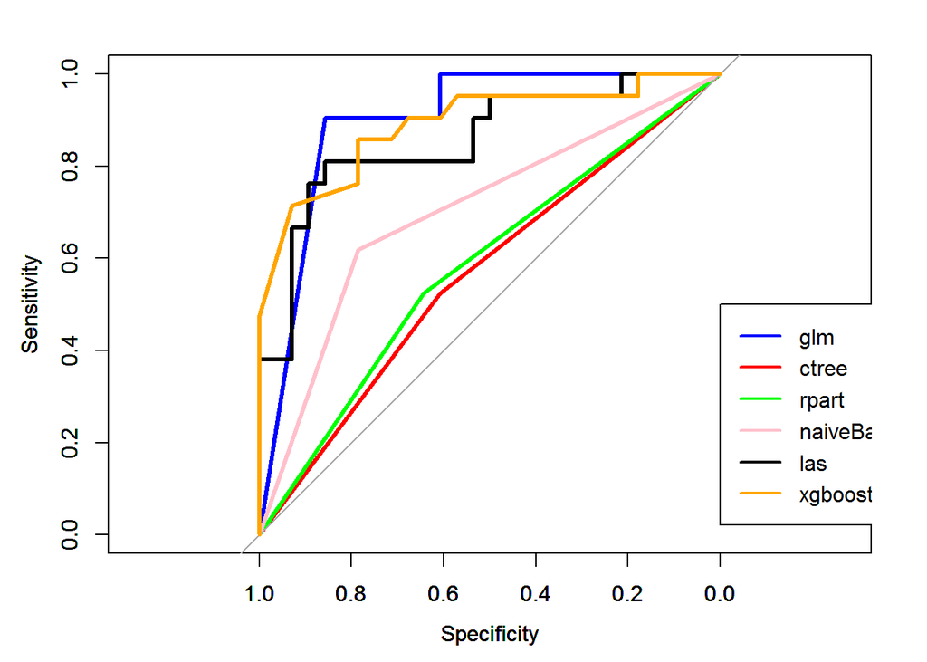

```r
cs2[3,6]=roc_reg$auc

legend(x=0, y=0.5, legend = c("glm", "ctree", "rpart", "naiveBayes", "las", "xgboost"), col = c("blue", "red", "green", "pink", "black", "orange"), lwd=c(2, 2))
```

**Weryfikacja powyższych wyników poprzez większą liczbę iteracji, i analiza tabeli kontyngencji:**

```r
set.seed(12345)


cs2<-matrix(0,4,6)
colnames(cs2)<-c("glm", "ctree", "rpart", "naiveBayes", "las", "xgboost")
rownames(cs2)<-c("czulosc", "specyficznosc", "auc", "F1")

for (i in 1:1000){
subset<-createResample(Dane2$death1y, times=1, list=FALSE)
#subset<-createResample(Dane2$death1y, times = 1, list = FALSE)

regresja <- glm(death1y~., data=Danreg[subset,], family="binomial", control = list(maxit = 50))
oceny<-predict(regresja, newdata=Danreg[-subset,], type="response")
t<-table(predykcja = (oceny>0.5), prawdziwe = Danreg[-subset,1])
p<-t[1,1]/(t[1,1]+t[1,2])
r<-t[1,1]/(t[1,1]+t[2,1])
cs2[1,1]=cs2[1,1]+t[1,1]/(t[1,1]+t[2,1])
cs2[2,1]=cs2[2,1]+t[2,2]/(t[2,2]+t[1,2])
cs2[3,1]=cs2[3,1]+roc(Danreg[-subset,]$death1y, oceny, direction="<")$auc
cs2[4,1]=cs2[4,1]+(2*p*r)/(p+r)

drzewo <- ctree(death1y~., data=Dan[subset,], control=ctree_control(mincriterion = 0.75, testtype="Bonferroni"))
  oceny <- predict(drzewo, newdata=Dan[-subset,])
t<-table(predykcja = oceny, prawdziwe = Dan[-subset,1])
p<-t[1,1]/(t[1,1]+t[1,2])
r<-t[1,1]/(t[1,1]+t[2,1])
cs2[1,2]=cs2[1,2]+t[1,1]/(t[1,1]+t[2,1])
cs2[2,2]=cs2[2,2]+t[2,2]/(t[2,2]+t[1,2])
cs2[3,2]=cs2[3,2]+roc(Dan[-subset,]$death1y, as.numeric(oceny), direction="<")$auc
cs2[4,2]=cs2[4,2]+(2*p*r)/(p+r)

drzewwo <- rpart(death1y~., data=Dan[subset,])
oceny<-predict(drzewwo, newdata=Dan[-subset,], type="class")
t<-table(predykcja = oceny, prawdziwe = Dan[-subset,1])
p<-t[1,1]/(t[1,1]+t[1,2])
r<-t[1,1]/(t[1,1]+t[2,1])
cs2[1,3]=cs2[1,3]+t[1,1]/(t[1,1]+t[2,1])
cs2[2,3]=cs2[2,3]+t[2,2]/(t[2,2]+t[1,2])
cs2[3,3]=cs2[3,3]+roc(Dan[-subset,]$death1y, as.numeric(oceny), direction="<")$auc
cs2[4,3]=cs2[4,3]+(2*p*r)/(p+r)

nb <- naiveBayes(death1y ~., data=Dan[subset,])
oceny <- predict(nb, newdata=Dan[-subset,])
t<-table(predykcja = oceny, prawdziwe = Dan[-subset,1])
p<-t[1,1]/(t[1,1]+t[1,2])
r<-t[1,1]/(t[1,1]+t[2,1])
cs2[1,4]=cs2[1,4]+t[1,1]/(t[1,1]+t[2,1])
cs2[2,4]=cs2[2,4]+t[2,2]/(t[2,2]+t[1,2])
cs2[3,4]=cs2[3,4]+roc(Dan[-subset,]$death1y, as.numeric(oceny), direction="<")$auc
cs2[4,4]=cs2[4,4]+(2*p*r)/(p+r)

rf <- randomForest(death1y~., Danlas[subset,])
oceny <- predict(rf, newdata=Danlas[-subset,], ntree=330)
t<-table(predykcja = (oceny>.5), prawdziwe = Danlas[-subset,1])
p<-t[1,1]/(t[1,1]+t[1,2])
r<-t[1,1]/(t[1,1]+t[2,1])
cs2[1,5]=cs2[1,5]+t[1,1]/(t[1,1]+t[2,1])
cs2[2,5]=cs2[2,5]+t[2,2]/(t[2,2]+t[1,2])
cs2[3,5]=cs2[3,5]+roc(Danlas[-subset,]$death1y, as.numeric(oceny), direction="<")$auc
cs2[4,5]=cs2[4,5]+(2*p*r)/(p+r)

X = as.matrix(Danxg[subset,-1])
xgb <- xgboost(data=X, label=igrek[subset],
                  objective = "binary:logistic",
                  nrounds = 3,
                  max.depth=4,
                  verbose=0)
oceny <- predict(xgb, as.matrix(Danxg[-subset,-1]))
t<-table(predykcja = (oceny>0.5), prawdziwe = Danxg[-subset,1])
p<-t[1,1]/(t[1,1]+t[1,2])
r<-t[1,1]/(t[1,1]+t[2,1])
cs2[1,6]=cs2[1,6]+t[1,1]/(t[1,1]+t[2,1])
cs2[2,6]=cs2[2,6]+t[2,2]/(t[2,2]+t[1,2])
cs2[3,6]=cs2[3,6]+roc(Danxg[-subset,]$death1y, as.numeric(oceny), direction="<")$auc
cs2[4,6]=cs2[4,6]+(2*p*r)/(p+r)
}
```

Wynik testu - czulosc (% dobrze przewidzanych jako dead) oraz specyficznosc (% dobrze przewidzianych jako alive), pole pod krzywa ROC i wspolczynnik F1 (opisany na kaggle):

```
##                     glm     ctree     rpart naiveBayes       las   xgboost
## czulosc       0.7720048 0.6486375 0.6282269  0.7309325 0.8047623 0.7830658
## specyficznosc 0.7546405 0.5959215 0.6185818  0.6767391 0.7641942 0.7255089
## auc           0.8169065 0.6222795 0.6234044  0.7038358 0.8745022 0.8118963
## F1            0.7633013 0.6218293 0.6182160  0.7094039 0.7844270 0.7570225
```

**4. Krzywe ROC dla podziału standardowego:**

```r
set.seed(12341)
subset<-createDataPartition(Dane2$death1y, times = 1, list = FALSE)

cs<-matrix(0,3,6)
colnames(cs)<-c("glm", "ctree", "rpart", "naiveBayes", "las", "xgboost")
rownames(cs)<-c("czulosc", "specyficznosc", "auc")


regresja <- glm(death1y~., data=Danreg[subset,], family="binomial", control = list(maxit = 50))
oceny<-predict(regresja, newdata=Danreg[-subset,], type="response")
t<-table(predykcja = (oceny > .5), prawdziwe = Danreg[-subset,1])

cs[1,1]=t[1,1]/(t[1,1]+t[2,1])
cs[2,1]=t[2,2]/(t[2,2]+t[1,2])

#roc dla regresji

roc_reg<-roc(Danreg[-subset,]$death1y, oceny, direction="<")
plot(roc_reg, col = "blue", lwd = 3)
```

ROC dla regresji

```
##
## Call:
## roc.default(response = Danreg[-subset, ]$death1y, predictor = oceny,     direction = "<")
##
## Data: oceny in 29 controls (Danreg[-subset, ]$death1y 0) < 33 cases (Danreg[-subset, ]$death1y 1).
## Area under the curve: 0.732
```

```r
cs[3,1]=roc_reg$auc


drzewo <- ctree(death1y~., data=Dan[subset,], control=ctree_control(mincriterion = 0.75, testtype="Bonferroni"))
oceny <- predict(drzewo, newdata=Dan[-subset,])

t<-table(predykcja = oceny, prawdziwe = Dan[-subset,1])

cs[1,2]=t[1,1]/(t[1,1]+t[2,1])
cs[2,2]=t[2,2]/(t[2,2]+t[1,2])

#roc dla drzewa 1
par(new=TRUE)
roc_reg<-roc(Dane2[-subset,c(4,y)]$death1y, as.numeric(oceny), direction="<")
plot(roc_reg, col = "red", lwd = 3)
```

ROC dla ctree

```
##
## Call:
## roc.default(response = Dane2[-subset, c(4, y)]$death1y, predictor = as.numeric(oceny),     direction = "<")
##
## Data: as.numeric(oceny) in 29 controls (Dane2[-subset, c(4, y)]$death1y 0) < 33 cases (Dane2[-subset, c(4, y)]$death1y 1).
## Area under the curve: 0.5162
```

```r
cs[3,2]=roc_reg$auc

  drzewwo <- rpart(death1y~., data=Dan[subset,])
oceny<-predict(drzewwo, newdata=Dan[-subset,], type="class")
t<-table(predykcja = oceny, prawdziwe = Dan[-subset,1])

cs[1,3]=t[1,1]/(t[1,1]+t[2,1])
cs[2,3]=t[2,2]/(t[2,2]+t[1,2])

#roc dla drzewa 2
par(new=TRUE)
roc_reg<-roc(Dane2[-subset,c(4,y)]$death1y, as.numeric(oceny), direction="<")
plot(roc_reg, col = "green", lwd = 3)
```

ROC dla rpart

```
##
## Call:
## roc.default(response = Dane2[-subset, c(4, y)]$death1y, predictor = as.numeric(oceny),     direction = "<")
##
## Data: as.numeric(oceny) in 29 controls (Dane2[-subset, c(4, y)]$death1y 0) < 33 cases (Dane2[-subset, c(4, y)]$death1y 1).
## Area under the curve: 0.5439
```

```r
cs[3,3]=roc_reg$auc


nb <- naiveBayes(death1y ~., data=Dan[subset,])
oceny <- predict(nb, newdata=Dan[-subset,])
t<-table(predykcja = oceny, prawdziwe = Dan[-subset,1])

cs[1,4]=t[1,1]/(t[1,1]+t[2,1])
cs[2,4]=t[2,2]/(t[2,2]+t[1,2])

#roc dla nb
par(new=TRUE)
roc_reg<-roc(Dane2[-subset,c(4,y)]$death1y, as.numeric(oceny), direction="<")
plot(roc_reg, col = "pink", lwd = 3)
```

ROC dla NB

```
##
## Call:
## roc.default(response = Dane2[-subset, c(4, y)]$death1y, predictor = as.numeric(oceny),     direction = "<")
##
## Data: as.numeric(oceny) in 29 controls (Dane2[-subset, c(4, y)]$death1y 0) < 33 cases (Dane2[-subset, c(4, y)]$death1y 1).
## Area under the curve: 0.6651
```

```r
cs[3,4]=roc_reg$auc

rf <- randomForest(death1y~., Danlas[subset,], ntree=330)
oceny <- predict(rf, newdata=Danlas[-subset,])
t<-table(predykcja = oceny>.5, prawdziwe = Danlas[-subset,1])

cs[1,5]=t[1,1]/(t[1,1]+t[2,1])
cs[2,5]=t[2,2]/(t[2,2]+t[1,2])

#roc dla lasu
par(new=TRUE)
roc_reg<-roc(Danlas[-subset,]$death1y, as.numeric(oceny), direction="<")
plot(roc_reg, col = "black", lwd = 3)
```

ROC dla lasu

```
##
## Call:
## roc.default(response = Danlas[-subset, ]$death1y, predictor = as.numeric(oceny),     direction = "<")
##
## Data: as.numeric(oceny) in 29 controls (Danlas[-subset, ]$death1y 0) < 33 cases (Danlas[-subset, ]$death1y 1).
## Area under the curve: 0.8349
```

```r
cs[3,5]=roc_reg$auc


X = as.matrix(Danxg[subset,-1])
xgb <- xgboost(data=X, label=igrek[subset],
                  objective = "binary:logistic",
                  nrounds = 3,
                  max.deph = 4,
                  verbose=0)
oceny <- predict(xgb, as.matrix(Danxg[-subset,-1]))
t<-table(predykcja = (oceny>0.5), prawdziwe = Danxg[-subset,1])

cs[1,6]=t[1,1]/(t[1,1]+t[2,1])
cs[2,6]=t[2,2]/(t[2,2]+t[1,2])

#roc dla xgb
par(new=TRUE)
roc_reg<-roc(Danxg[-subset,]$death1y, as.numeric(oceny), direction="<")
plot(roc_reg, col = "orange", lwd = 3)
```

ROC dla XGB

```
##
## Call:
## roc.default(response = Danxg[-subset, ]$death1y, predictor = as.numeric(oceny),     direction = "<")
##
## Data: as.numeric(oceny) in 29 controls (Danxg[-subset, ]$death1y 0) < 33 cases (Danxg[-subset, ]$death1y 1).
## Area under the curve: 0.72
```

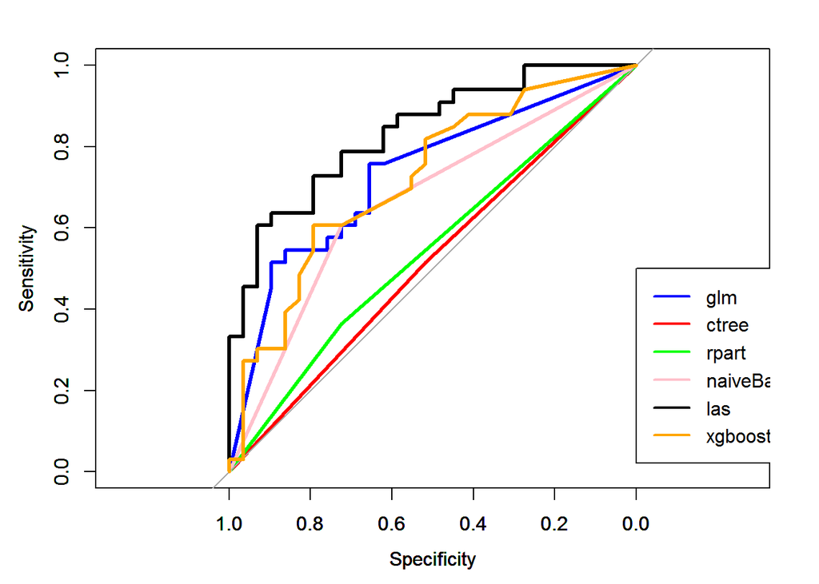

```r
cs[3,6]=roc_reg$auc

legend(x=0, y=0.5, legend = c("glm", "ctree", "rpart", "naiveBayes", "las", "xgboost"), col = c("blue", "red", "green", "pink", "black", "orange"), lwd=c(2, 2))
```

**Weryfikacja powyższych wyników poprzez większą liczbę iteracji, i analiza tabeli kontyngencji:**

```r
set.seed(12345)


cs<-matrix(0,4,6)
colnames(cs)<-c("glm", "ctree", "rpart", "naiveBayes", "las", "xgboost")
rownames(cs)<-c("czulosc", "specyficznosc", "auc", "F1")

for (i in 1:1000){
subset<-createDataPartition(Dane2$death1y, times=1, p=0.75, list=FALSE)
#subset<-createResample(Dane2$death1y, times = 1, list = FALSE)

regresja <- glm(death1y~., data=Danreg[subset,], family="binomial", control = list(maxit = 50))
oceny<-predict(regresja, newdata=Danreg[-subset,], type="response")
t<-table(predykcja = (oceny>0.5), prawdziwe = Danreg[-subset,1])
p<-t[1,1]/(t[1,1]+t[1,2])
r<-t[1,1]/(t[1,1]+t[2,1])
cs[1,1]=cs[1,1]+t[1,1]/(t[1,1]+t[2,1])
cs[2,1]=cs[2,1]+t[2,2]/(t[2,2]+t[1,2])
cs[3,1]=cs[3,1]+roc(Danreg[-subset,]$death1y, oceny, direction="<")$auc
cs[4,1]=cs[4,1]+(2*p*r)/(p+r)

drzewo <- ctree(death1y~., data=Dan[subset,], control=ctree_control(mincriterion = 0.75, testtype="Bonferroni"))
  oceny <- predict(drzewo, newdata=Dan[-subset,])
t<-table(predykcja = oceny, prawdziwe = Dan[-subset,1])
p<-t[1,1]/(t[1,1]+t[1,2])
r<-t[1,1]/(t[1,1]+t[2,1])
cs[1,2]=cs[1,2]+t[1,1]/(t[1,1]+t[2,1])
cs[2,2]=cs[2,2]+t[2,2]/(t[2,2]+t[1,2])
cs[3,2]=cs[3,2]+roc(Dan[-subset,]$death1y, as.numeric(oceny), direction="<")$auc
cs[4,2]=cs[4,2]+(2*p*r)/(p+r)

drzewwo <- rpart(death1y~., data=Dan[subset,])
oceny<-predict(drzewwo, newdata=Dan[-subset,], type="class")
t<-table(predykcja = oceny, prawdziwe = Dan[-subset,1])
p<-t[1,1]/(t[1,1]+t[1,2])
r<-t[1,1]/(t[1,1]+t[2,1])
cs[1,3]=cs[1,3]+t[1,1]/(t[1,1]+t[2,1])
cs[2,3]=cs[2,3]+t[2,2]/(t[2,2]+t[1,2])
cs[3,3]=cs[3,3]+roc(Dan[-subset,]$death1y, as.numeric(oceny), direction="<")$auc
cs[4,3]=cs[4,3]+(2*p*r)/(p+r)

nb <- naiveBayes(death1y ~., data=Dan[subset,])
oceny <- predict(nb, newdata=Dan[-subset,])
t<-table(predykcja = oceny, prawdziwe = Dan[-subset,1])
p<-t[1,1]/(t[1,1]+t[1,2])
r<-t[1,1]/(t[1,1]+t[2,1])
cs[1,4]=cs[1,4]+t[1,1]/(t[1,1]+t[2,1])
cs[2,4]=cs[2,4]+t[2,2]/(t[2,2]+t[1,2])
cs[3,4]=cs[3,4]+roc(Dan[-subset,]$death1y, as.numeric(oceny), direction="<")$auc
cs[4,4]=cs[4,4]+(2*p*r)/(p+r)

rf <- randomForest(death1y~., Danlas[subset,])
oceny <- predict(rf, newdata=Danlas[-subset,], ntree=330)
t<-table(predykcja = (oceny>.5), prawdziwe = Danlas[-subset,1])
p<-t[1,1]/(t[1,1]+t[1,2])
r<-t[1,1]/(t[1,1]+t[2,1])
cs[1,5]=cs[1,5]+t[1,1]/(t[1,1]+t[2,1])
cs[2,5]=cs[2,5]+t[2,2]/(t[2,2]+t[1,2])
cs[3,5]=cs[3,5]+roc(Danlas[-subset,]$death1y, as.numeric(oceny), direction="<")$auc
cs[4,5]=cs[4,5]+(2*p*r)/(p+r)

X = as.matrix(Danxg[subset,-1])
xgb <- xgboost(data=X, label=igrek[subset],
                  objective = "binary:logistic",
                  nrounds = 3,
                  max.depth=4,
                  verbose=0)
oceny <- predict(xgb, as.matrix(Danxg[-subset,-1]))
t<-table(predykcja = (oceny>0.5), prawdziwe = Danxg[-subset,1])
p<-t[1,1]/(t[1,1]+t[1,2])
r<-t[1,1]/(t[1,1]+t[2,1])
cs[1,6]=cs[1,6]+t[1,1]/(t[1,1]+t[2,1])
cs[2,6]=cs[2,6]+t[2,2]/(t[2,2]+t[1,2])
cs[3,6]=cs[3,6]+roc(Danxg[-subset,]$death1y, as.numeric(oceny), direction="<")$auc
cs[4,6]=cs[4,6]+(2*p*r)/(p+r)
}
```

Wynik testu - czulosc (% dobrze przewidzanych jako dead) oraz specyficznosc (% dobrze przewidzianych jako alive), pole pod krzywa ROC i wspolczynnik F1 (opisany na kaggle):

```
##                     glm     ctree     rpart naiveBayes       las   xgboost
## czulosc       0.7866446 0.6730560 0.6298307  0.7430158 0.8291391 0.8408849
## specyficznosc 0.7733471 0.5429326 0.6222680  0.6782452 0.7801325 0.7459574
## auc           0.8286567 0.6079943 0.6260493  0.7106305 0.8903941 0.8480253
## F1            0.7756821 0.6152666 0.6148534  0.7135359 0.8015593 0.7958340
```

# Teraz Zamiana NA poprzez srednie.

```r
Dane2<-Dane[,!maska]
srednie<-apply(Dane2[,-(1:4)], 2, function(x){mean(x, na.rm = TRUE)})
for (i in 1:nrow(Dane2)) {
  Dane2[i,-(1:4)][is.na(Dane2[i,-(1:4)])]<-srednie[is.na(Dane2[i,-(1:4)])]
}
```

**1. n-fold**

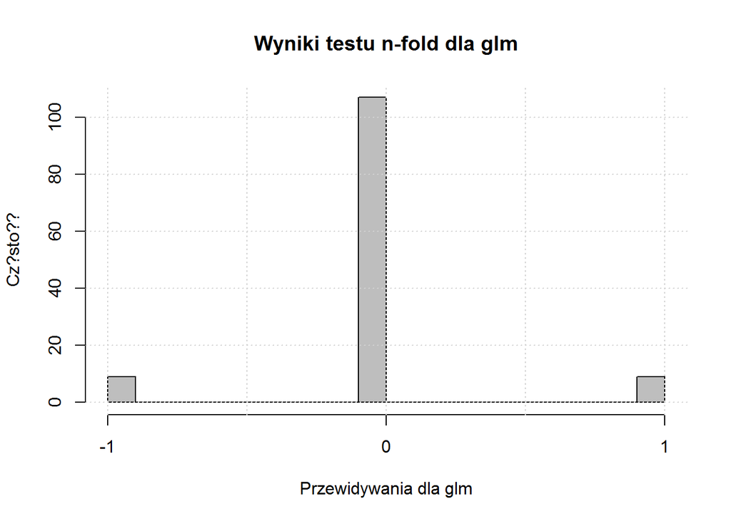

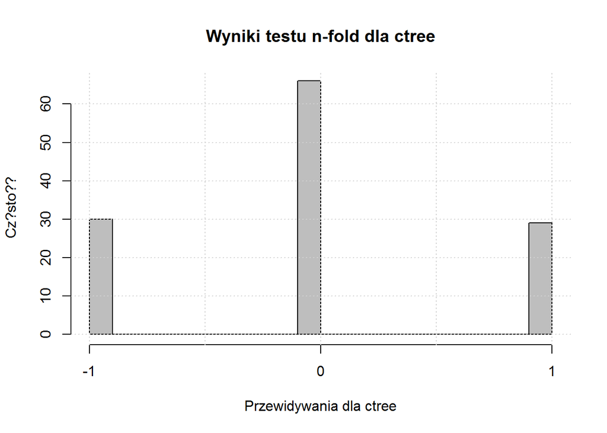

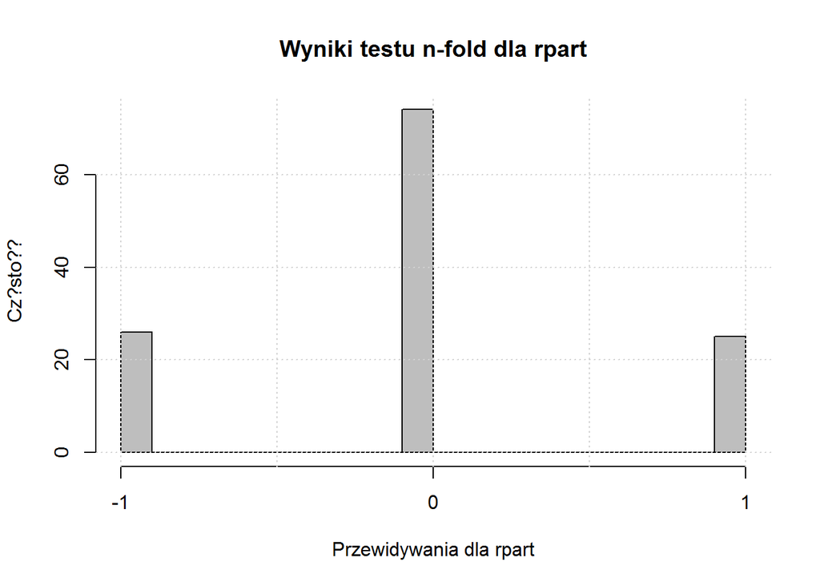

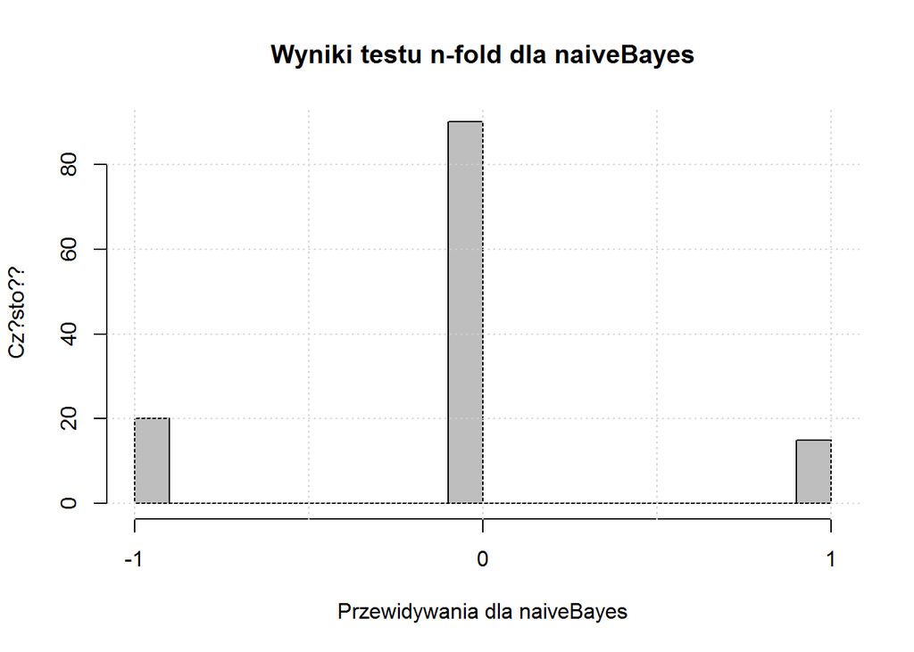

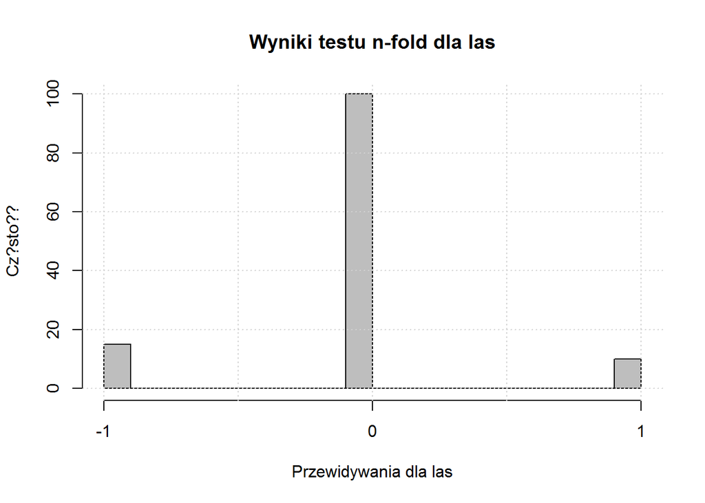

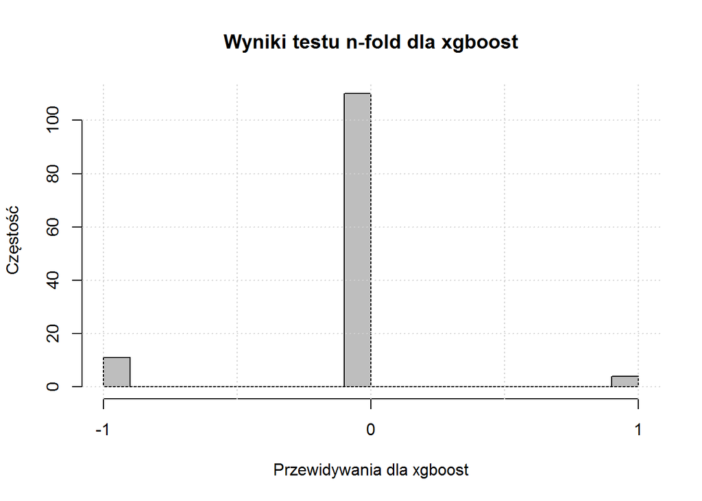

Wynik testu:

```
##    glm ctree rpart naiveBayes las xgboost
## 1    9    29    25         15  10       4
## 0  107    66    74         90 100     110
## -1   9    30    26         20  15      11
```

**2. Repeated k-fold CV (100 razy 10-fold)**

Wynik testu:

```
##      glm ctree rpart naiveBayes   las xgboost
## 1  12.56 22.32 25.54      16.52 11.40    6.58
## 0  99.78 74.54 76.33      88.48 99.04  105.80
## -1 12.66 28.14 23.13      20.00 14.56   12.62
```

**3. Krzywe ROC dla podziału bootstrap:**

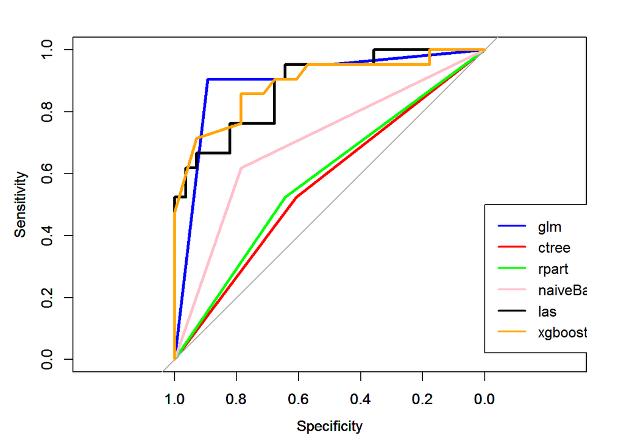

**Weryfikacja powyższych wyników poprzez większą liczbę iteracji, i analiza tabeli kontyngencji:**

Wynik testu - czulosc (% dobrze przewidzanych jako dead) oraz specyficznosc (% dobrze przewidzianych jako alive), pole pod krzywa ROC i wspolczynnik F1 (opisany na kaggle)::

```
##                     glm     ctree     rpart naiveBayes       las   xgboost
## czulosc       0.7686064 0.6439757 0.6195531  0.7274069 0.7949624 0.7825279
## specyficznosc 0.7579676 0.5978446 0.6178457  0.6723815 0.7640764 0.7269056
## auc           0.8156209 0.6209102 0.6186994  0.6998942 0.8787344 0.8130395
## F1            0.7624990 0.6205813 0.6119000  0.7058166 0.7785206 0.7571677
```

**4. Krzywe ROC dla podziału standardowego:**

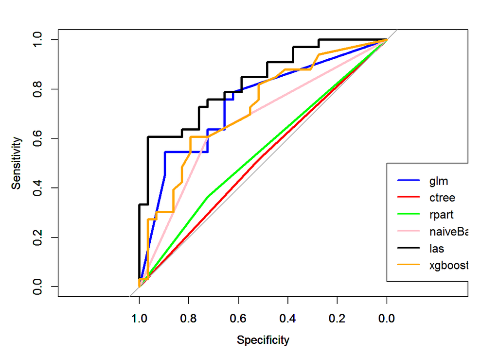

**Weryfikacja powyższych wyników poprzez większą liczbę iteracji, i analiza tabeli kontyngencji:**

Wynik testu - czulosc (% dobrze przewidzanych jako dead) oraz specyficznosc (% dobrze przewidzianych jako alive), pole pod krzywa ROC i wspolczynnik F1 (opisany na kaggle)::

```
##                     glm     ctree     rpart naiveBayes       las   xgboost
## czulosc       0.7823417 0.6573259 0.6131279  0.7386711 0.8141412 0.8398806
## specyficznosc 0.7742113 0.5582989 0.6173052  0.6739266 0.7751802 0.7487346
## auc           0.8272529 0.6078124 0.6152165  0.7062989 0.8943623 0.8499486
## F1            0.7745689 0.6106419 0.6041531  0.7105138 0.7919143 0.7972088
```